# Pertemuan 7

Muhamad Fawaz Zidan (G1401211051)

### Library

```r
library("forecast")
```

```r
library("graphics")
library("TTR")
library("TSA")
library(dplyr)
library(forecast)
library(lmtest)
library(orcutt)
library(HoRM)
library(corrplot)
library(dLagM)
library(dynlm)
library(MLmetrics)
library(ggplot2)
library(tsibble)
library(tseries)
library(MASS)
library(aTSA)
```

# Input data

```r
library(readxl)
data <- read_excel("C:/Users/ASUS/OneDrive/Kuliah/Smt 5/MPDW/Pertemuan 7/Data MPDW.xlsx",sheet=3)
View(data)
```

### Ubah data menjadi time series

```r
data.ts <- ts(data$Suhu)
```

### Membagi data menjadi data latih (80%) dan data uji (20%) dan jadikan time series

```r
dt.latih <- data[1:200,2]
dt.uji <- data[201:250,2]
dt.latih.ts <- ts(dt.latih, frequency = 12)
dt.uji.ts <- ts(dt.uji, frequency = 12)
```

# Eksplorasi data

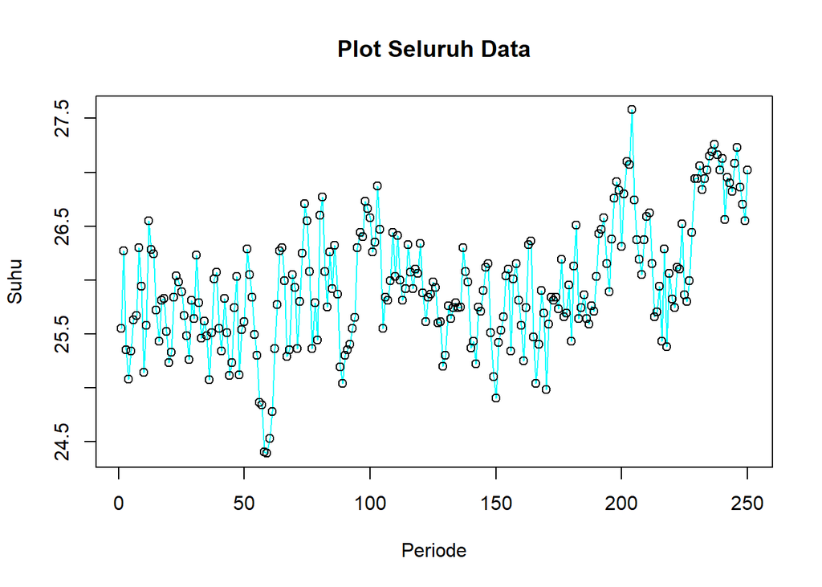

```r
# data full
ts.plot(data.ts, col="cyan",main="Plot Seluruh Data", type="o",xlab="Periode",ylab="Suhu")
points(data.ts)
```

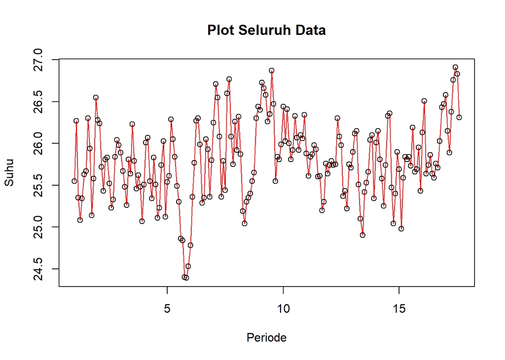

```r
# data latih
ts.plot(dt.latih.ts, col="red",main="Plot Seluruh Data", type="o",xlab="Periode",ylab="Suhu")
points(dt.latih.ts)
```

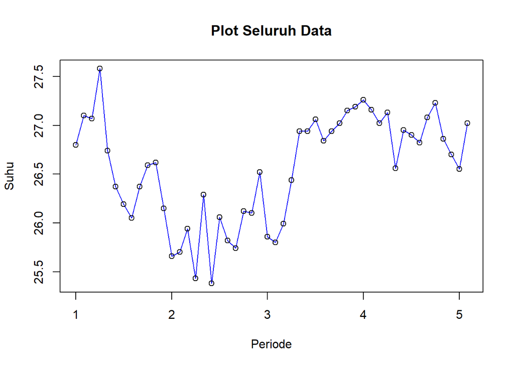

```r
# data uji
ts.plot(dt.uji.ts, col="blue",main="Plot Seluruh Data", type="o",xlab="Periode",ylab="Suhu")
points(dt.uji.ts)
```

# CEK Stasioner

### Plot acf

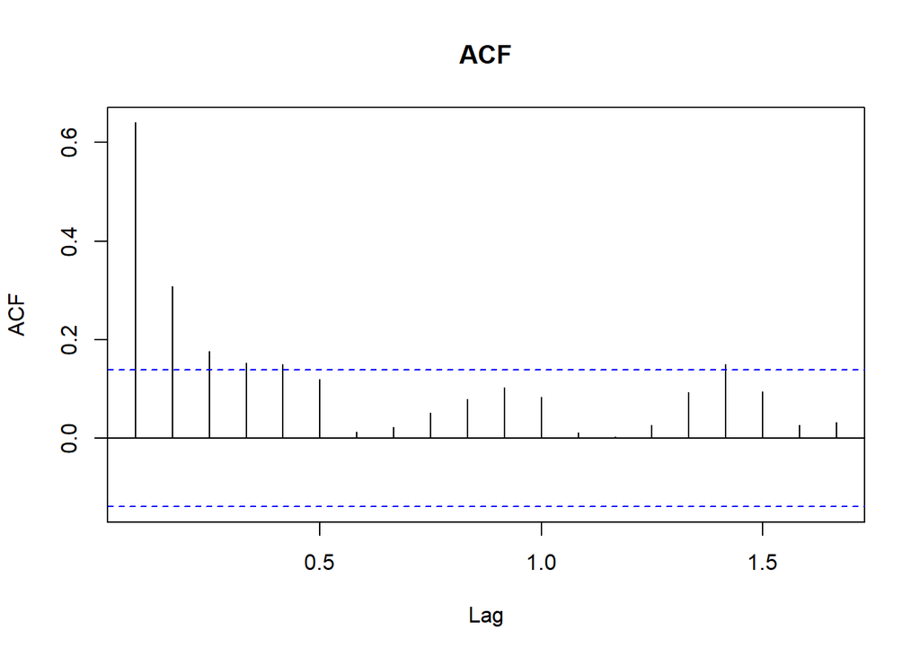

```r
acf(dt.latih.ts, main="ACF", lag.max=20)
```

Berdasarkan plot ACF, terlihat bahwa plot ACF pada data tersebut cenderung *tails off* serta menandakan bahwa data tersebut terindikasi stasioner dalam rataan

### Uji ADF

```r
tseries::adf.test(dt.latih.ts)
```

```
##
##  Augmented Dickey-Fuller Test
##
## data:  dt.latih.ts
## Dickey-Fuller = -4.1595, Lag order = 5, p-value = 0.01
## alternative hypothesis: stationary
```

$H_0$ : Data tidak stasioner dalam rataan

$H_1$ : Data stasioner dalam rataan

Berdasarkan uji ADF tersebut, didapat *p-value* sebesar 0.01 yang lebih kecil dari taraf nyata 5% sehingga tolak $H_0$ dan menandakan bahwa data stasioner dalam rataan. Hal ini sesuai dengan hasil eksplorasi menggunakan plot time series dan plot ACF.

### Plot Box-Cox

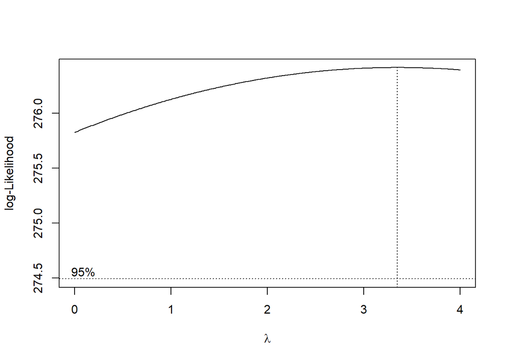

```r
index <- seq(1:200)
bc = boxcox(dt.latih.ts~index, lambda = seq(0,4,by=0.01))
```

```r
#Nilai Rounded Lambda
lambda <- bc$x[which.max(bc$y)]
lambda
```

```
## [1] 3.35
```

```r
#SK
bc$x[bc$y > max(bc$y) - 1/2 * qchisq(.95,1)]
```

```
##   [1] 0.00 0.01 0.02 0.03 0.04 0.05 0.06 0.07 0.08 0.09 0.10 0.11 0.12 0.13 0.14
##  [16] 0.15 0.16 0.17 0.18 0.19 0.20 0.21 0.22 0.23 0.24 0.25 0.26 0.27 0.28 0.29
##  [31] 0.30 0.31 0.32 0.33 0.34 0.35 0.36 0.37 0.38 0.39 0.40 0.41 0.42 0.43 0.44
##  [46] 0.45 0.46 0.47 0.48 0.49 0.50 0.51 0.52 0.53 0.54 0.55 0.56 0.57 0.58 0.59
##  [61] 0.60 0.61 0.62 0.63 0.64 0.65 0.66 0.67 0.68 0.69 0.70 0.71 0.72 0.73 0.74
##  [76] 0.75 0.76 0.77 0.78 0.79 0.80 0.81 0.82 0.83 0.84 0.85 0.86 0.87 0.88 0.89
##  [91] 0.90 0.91 0.92 0.93 0.94 0.95 0.96 0.97 0.98 0.99 1.00 1.01 1.02 1.03 1.04
## [106] 1.05 1.06 1.07 1.08 1.09 1.10 1.11 1.12 1.13 1.14 1.15 1.16 1.17 1.18 1.19
## [121] 1.20 1.21 1.22 1.23 1.24 1.25 1.26 1.27 1.28 1.29 1.30 1.31 1.32 1.33 1.34
## [136] 1.35 1.36 1.37 1.38 1.39 1.40 1.41 1.42 1.43 1.44 1.45 1.46 1.47 1.48 1.49
## [151] 1.50 1.51 1.52 1.53 1.54 1.55 1.56 1.57 1.58 1.59 1.60 1.61 1.62 1.63 1.64
## [166] 1.65 1.66 1.67 1.68 1.69 1.70 1.71 1.72 1.73 1.74 1.75 1.76 1.77 1.78 1.79
## [181] 1.80 1.81 1.82 1.83 1.84 1.85 1.86 1.87 1.88 1.89 1.90 1.91 1.92 1.93 1.94
## [196] 1.95 1.96 1.97 1.98 1.99 2.00 2.01 2.02 2.03 2.04 2.05 2.06 2.07 2.08 2.09
## [211] 2.10 2.11 2.12 2.13 2.14 2.15 2.16 2.17 2.18 2.19 2.20 2.21 2.22 2.23 2.24
## [226] 2.25 2.26 2.27 2.28 2.29 2.30 2.31 2.32 2.33 2.34 2.35 2.36 2.37 2.38 2.39
## [241] 2.40 2.41 2.42 2.43 2.44 2.45 2.46 2.47 2.48 2.49 2.50 2.51 2.52 2.53 2.54
## [256] 2.55 2.56 2.57 2.58 2.59 2.60 2.61 2.62 2.63 2.64 2.65 2.66 2.67 2.68 2.69
## [271] 2.70 2.71 2.72 2.73 2.74 2.75 2.76 2.77 2.78 2.79 2.80 2.81 2.82 2.83 2.84
## [286] 2.85 2.86 2.87 2.88 2.89 2.90 2.91 2.92 2.93 2.94 2.95 2.96 2.97 2.98 2.99
## [301] 3.00 3.01 3.02 3.03 3.04 3.05 3.06 3.07 3.08 3.09 3.10 3.11 3.12 3.13 3.14
## [316] 3.15 3.16 3.17 3.18 3.19 3.20 3.21 3.22 3.23 3.24 3.25 3.26 3.27 3.28 3.29
## [331] 3.30 3.31 3.32 3.33 3.34 3.35 3.36 3.37 3.38 3.39 3.40 3.41 3.42 3.43 3.44
## [346] 3.45 3.46 3.47 3.48 3.49 3.50 3.51 3.52 3.53 3.54 3.55 3.56 3.57 3.58 3.59
## [361] 3.60 3.61 3.62 3.63 3.64 3.65 3.66 3.67 3.68 3.69 3.70 3.71 3.72 3.73 3.74
## [376] 3.75 3.76 3.77 3.78 3.79 3.80 3.81 3.82 3.83 3.84 3.85 3.86 3.87 3.88 3.89
## [391] 3.90 3.91 3.92 3.93 3.94 3.95 3.96 3.97 3.98 3.99 4.00
```

Gambar di atas menunjukkan nilai *rounded value* ($\lambda$) optimum sebesar **3.35** dan pada selang kepercayaan 95% nilai memiliki batas bawah **0.00** dan batas atas **4.00**. Selang tersebut memuat nilai satu sehingga dapat dikatakan bahwa data bangkitan stasioner dalam ragam.

# Identifikasi model

### Plot ACF dan PACF

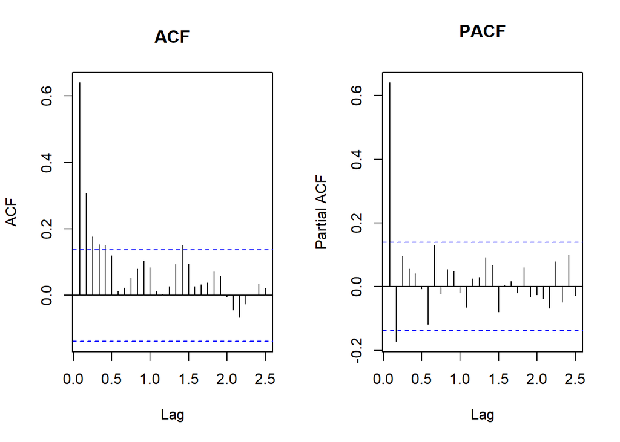

```r
par(mfrow = c(1,2))
acf(dt.latih.ts, main="ACF", lag.max=30) #ARIMA(0,0,2)
pacf(dt.latih.ts, main="PACF", lag.max=30) #ARIMA(1,0,0)
```

### Plot EACF

```r
eacf(dt.latih.ts)
```

```
## AR/MA
##   0 1 2 3 4 5 6 7 8 9 10 11 12 13
## 0 x x x x x o o o o o o  o  o  o
## 1 x o x o o o o o o o o  o  o  o
## 2 x x o o o o o o o o o  o  o  o
## 3 x o o o o o x o o o o  o  o  o
## 4 x o o o o o x o o o o  o  o  o
## 5 x x o o o o x o o o o  o  o  o
## 6 o x o o x o x o o o o  o  o  o
## 7 x x o o x o x o o o o  o  o  o
```

identifikasi model menggunakan plot EACF dilakukan dengan melihat ujung segitiga pada pola segitiga nol. Dalam hal ini model tentatif yang terbentuk adalah ARIMA(3,0,1).

# Pendugaan Parameter

### ARIMA (0,0,1)

```r
model1=Arima(dt.latih.ts, order=c(0,0,1),method="ML")
summary(model1) #AIC=177.89
```

```
## Series: dt.latih.ts
## ARIMA(0,0,1) with non-zero mean
##
## Coefficients:
##          ma1     mean
##       0.6025  25.7987
## s.e.  0.0441   0.0420
##
## sigma^2 = 0.1394:  log likelihood = -85.95
## AIC=177.89   AICc=178.02   BIC=187.79
##
## Training set error measures:
##                      ME      RMSE       MAE         MPE     MAPE      MASE
## Training set 0.00116562 0.3714537 0.2984157 -0.01869412 1.157624 0.6021483
##                   ACF1
## Training set 0.1900373
```

```r
lmtest::coeftest(model1) #signifikan
```

```
##
## z test of coefficients:
##
##            Estimate Std. Error z value  Pr(>|z|)
## ma1        0.602546   0.044120  13.657 < 2.2e-16 ***
## intercept 25.798704   0.042014 614.053 < 2.2e-16 ***
## ---
## Signif. codes:  0 '***' 0.001 '**' 0.01 '*' 0.05 '.' 0.1 ' ' 1
```

### ARIMA (0,0,3)

```r
model2=Arima(dt.latih.ts, order=c(0,0,3),method="ML")
summary(model2) #AIC=162.82
```

```
## Series: dt.latih.ts
## ARIMA(0,0,3) with non-zero mean
##
## Coefficients:
##          ma1     ma2     ma3     mean
##       0.7684  0.3348  0.0922  25.7982
## s.e.  0.0700  0.0846  0.0679   0.0547
##
## sigma^2 = 0.1279:  log likelihood = -76.41
## AIC=162.82   AICc=163.13   BIC=179.32
##
## Training set error measures:
##                       ME      RMSE       MAE         MPE     MAPE      MASE
## Training set 0.001355091 0.3540317 0.2852457 -0.01398286 1.106361 0.5755736
##                     ACF1
## Training set 0.005525333
```

```r
lmtest::coeftest(model2) #tidak signifikan
```

```
##
## z test of coefficients:
##
##            Estimate Std. Error  z value  Pr(>|z|)
## ma1        0.768408   0.069988  10.9792 < 2.2e-16 ***
## ma2        0.334764   0.084557   3.9590 7.525e-05 ***
## ma3        0.092213   0.067942   1.3572    0.1747
## intercept 25.798204   0.054750 471.2033 < 2.2e-16 ***
## ---
## Signif. codes:  0 '***' 0.001 '**' 0.01 '*' 0.05 '.' 0.1 ' ' 1
```

### ARIMA (3,0,1)

```r
model3=Arima(dt.latih.ts, order=c(3,0,1),method="ML")
summary(model3) #AIC=161.51
```

```
## Series: dt.latih.ts
## ARIMA(3,0,1) with non-zero mean
##
## Coefficients:
##          ar1      ar2     ar3      ma1     mean
##       1.2214  -0.5996  0.1970  -0.4544  25.8023
## s.e.  0.4045   0.3015  0.0836   0.4105   0.0739
##
## sigma^2 = 0.1264:  log likelihood = -74.75
## AIC=161.51   AICc=161.94   BIC=181.3
##
## Training set error measures:
##                      ME      RMSE       MAE         MPE     MAPE      MASE
## Training set 0.00215815 0.3510577 0.2865866 -0.01021403 1.111424 0.5782793
##                      ACF1
## Training set -0.005533977
```

```r
lmtest::coeftest(model3) #tidak Signifikan
```

```
##
## z test of coefficients:
##
##            Estimate Std. Error  z value  Pr(>|z|)
## ar1        1.221365   0.404494   3.0195  0.002532 **
## ar2       -0.599604   0.301518  -1.9886  0.046744 *
## ar3        0.196997   0.083624   2.3557  0.018485 *
## ma1       -0.454383   0.410509  -1.1069  0.268347
## intercept 25.802330   0.073903 349.1367 < 2.2e-16 ***
## ---
## Signif. codes:  0 '***' 0.001 '**' 0.01 '*' 0.05 '.' 0.1 ' ' 1
```

# analisis sisaan

### Eksplorasi

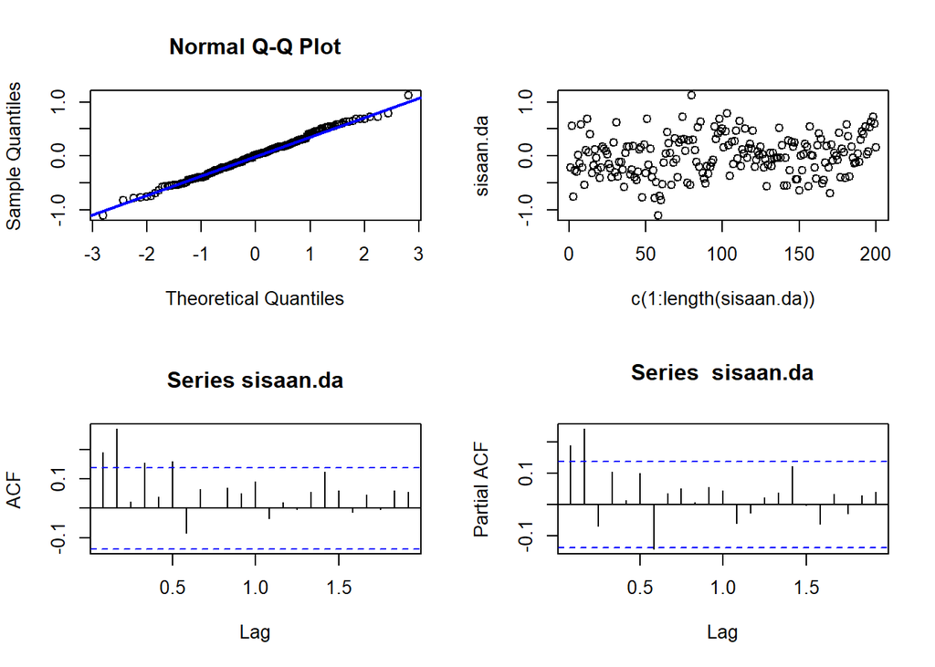

```r
#Eksplorasi
sisaan.da <- model1$residuals
par(mfrow=c(2,2))
qqnorm(sisaan.da)
qqline(sisaan.da, col = "blue", lwd = 2)
plot(c(1:length(sisaan.da)),sisaan.da)
acf(sisaan.da)
pacf(sisaan.da)
```

```r
par(mfrow = c(1,1))
```

### Uji Formal

```r
#1) Sisaan Menyebar Normal
ks.test(sisaan.da,"pnorm")
```

```
##
##  Asymptotic one-sample Kolmogorov-Smirnov test
##
## data:  sisaan.da
## D = 0.24172, p-value = 1.415e-10
## alternative hypothesis: two-sided
```

$H_0$ : Sisaan menyebar normal

$H_1$ : Sisaan tidak menyebar normal

```r
#2) Sisaan saling bebas/tidak ada autokorelasi
Box.test(sisaan.da, type = "Ljung")
```

```
##
##  Box-Ljung test
##
## data:  sisaan.da
## X-squared = 7.3317, df = 1, p-value = 0.006775
```

$H_0$ : Sisaan saling bebas

$H_1$ : Sisaan tidak tidak saling bebas

```r
#3) Sisaan homogen
Box.test((sisaan.da)^2, type = "Ljung")
```

```
##
##  Box-Ljung test
##
## data:  (sisaan.da)^2
## X-squared = 4.9744, df = 1, p-value = 0.02573
```

$H_0$ : Ragam sisaan homogen

$H_1$ : Ragam sisaan tidak homogen

```r
#4) Nilai tengah sisaan sama dengan nol
t.test(sisaan.da, mu = 0, conf.level = 0.95)  #tak tolak h0 > nilai tengah sisaan sama dengan 0
```

```
##
##  One Sample t-test
##
## data:  sisaan.da
## t = 0.044267, df = 199, p-value = 0.9647
## alternative hypothesis: true mean is not equal to 0
## 95 percent confidence interval:
##  -0.05075900  0.05309024
## sample estimates:
##  mean of x
## 0.00116562
```

$H_0$ : nilai tengah sisaan sama dengan 0

$H_1$ : nilai tengah sisaan tidak sama dengan 0

Berdasarkan uji-ttersebut, didapat *p-value* sebesar 0.9647 yang lebih besar dari taraf nyata 5% sehingga tak tolak $H_0$ dan menandakan bahwa nilai tengah sisaan sama dengan 0

# Overfitting

### ARIMA(1,0,1)

```r
model4=Arima(dt.latih.ts, order=c(1,0,1),method="ML")
summary(model4) #AIC=159.44
```

```
## Series: dt.latih.ts
## ARIMA(1,0,1) with non-zero mean
##
## Coefficients:
##          ar1     ma1     mean
##       0.4681  0.3050  25.7991
## s.e.  0.0921  0.1001   0.0609
##
## sigma^2 = 0.1264:  log likelihood = -75.72
## AIC=159.44   AICc=159.65   BIC=172.64
##
## Training set error measures:
##                       ME     RMSE       MAE         MPE    MAPE      MASE
## Training set 0.001377333 0.352799 0.2848741 -0.01343755 1.10484 0.5748238
##                      ACF1
## Training set -0.004097119
```

```r
lmtest::coeftest(model4) #signifikan
```

```
##
## z test of coefficients:
##
##            Estimate Std. Error  z value  Pr(>|z|)
## ar1        0.468106   0.092130   5.0809 3.756e-07 ***
## ma1        0.304953   0.100070   3.0474  0.002308 **
## intercept 25.799063   0.060871 423.8306 < 2.2e-16 ***
## ---
## Signif. codes:  0 '***' 0.001 '**' 0.01 '*' 0.05 '.' 0.1 ' ' 1
```

### ARIMA(0,0,2)

```r
model5=Arima(dt.latih.ts, order=c(0,0,2),method="ML")
summary(model5) #AIC=162.63
```

```
## Series: dt.latih.ts
## ARIMA(0,0,2) with non-zero mean
##
## Coefficients:
##          ma1     ma2     mean
##       0.7622  0.2590  25.7979
## s.e.  0.0684  0.0587   0.0507
##
## sigma^2 = 0.1284:  log likelihood = -77.31
## AIC=162.63   AICc=162.83   BIC=175.82
##
## Training set error measures:
##                       ME      RMSE       MAE         MPE     MAPE      MASE
## Training set 0.001422619 0.3556309 0.2873261 -0.01432701 1.114434 0.5797714
##                    ACF1
## Training set 0.02138272
```

```r
lmtest::coeftest(model4) #signifikan
```

[output not shown]

# Peramalan

```r
#---FORECAST---#
ramalan <- forecast::forecast(model4, h = 49)
ramalan
```

```
##        Point Forecast    Lo 80    Hi 80    Lo 95    Hi 95
## Sep 17       26.01361 25.55805 26.46916 25.31689 26.71032
## Oct 17       25.89949 25.32368 26.47530 25.01886 26.78012
## Nov 17       25.84607 25.24713 26.44502 24.93006 26.76209
## Dec 17       25.82107 25.21717 26.42497 24.89749 26.74465
## Jan 18       25.80936 25.20439 26.41434 24.88413 26.73460
## Feb 18       25.80388 25.19867 26.40910 24.87829 26.72948
## Mar 18       25.80132 25.19605 26.40659 24.87565 26.72699
## Apr 18       25.80012 25.19484 26.40540 24.87443 26.72581
## May 18       25.79956 25.19428 26.40484 24.87386 26.72525
## Jun 18       25.79929 25.19401 26.40457 24.87360 26.72499
## Jul 18       25.79917 25.19389 26.40445 24.87347 26.72487
## Aug 18       25.79911 25.19383 26.40439 24.87342 26.72481
## Sep 18       25.79909 25.19381 26.40437 24.87339 26.72478
## Oct 18       25.79907 25.19379 26.40435 24.87338 26.72477
## Nov 18       25.79907 25.19379 26.40435 24.87337 26.72476
## Dec 18       25.79907 25.19378 26.40435 24.87337 26.72476
## Jan 19       25.79906 25.19378 26.40434 24.87337 26.72476
## Feb 19       25.79906 25.19378 26.40434 24.87337 26.72476
## Mar 19       25.79906 25.19378 26.40434 24.87337 26.72476
## Apr 19       25.79906 25.19378 26.40434 24.87337 26.72476
## May 19       25.79906 25.19378 26.40434 24.87337 26.72476
## Jun 19       25.79906 25.19378 26.40434 24.87337 26.72476
## Jul 19       25.79906 25.19378 26.40434 24.87337 26.72476
## Aug 19       25.79906 25.19378 26.40434 24.87337 26.72476
## Sep 19       25.79906 25.19378 26.40434 24.87337 26.72476
## Oct 19       25.79906 25.19378 26.40434 24.87337 26.72476
## Nov 19       25.79906 25.19378 26.40434 24.87337 26.72476
## Dec 19       25.79906 25.19378 26.40434 24.87337 26.72476
## Jan 20       25.79906 25.19378 26.40434 24.87337 26.72476
## Feb 20       25.79906 25.19378 26.40434 24.87337 26.72476
## Mar 20       25.79906 25.19378 26.40434 24.87337 26.72476
## Apr 20       25.79906 25.19378 26.40434 24.87337 26.72476
## May 20       25.79906 25.19378 26.40434 24.87337 26.72476
## Jun 20       25.79906 25.19378 26.40434 24.87337 26.72476
## Jul 20       25.79906 25.19378 26.40434 24.87337 26.72476
## Aug 20       25.79906 25.19378 26.40434 24.87337 26.72476
## Sep 20       25.79906 25.19378 26.40434 24.87337 26.72476
## Oct 20       25.79906 25.19378 26.40434 24.87337 26.72476
## Nov 20       25.79906 25.19378 26.40434 24.87337 26.72476
## Dec 20       25.79906 25.19378 26.40434 24.87337 26.72476
## Jan 21       25.79906 25.19378 26.40434 24.87337 26.72476
## Feb 21       25.79906 25.19378 26.40434 24.87337 26.72476
## Mar 21       25.79906 25.19378 26.40434 24.87337 26.72476
## Apr 21       25.79906 25.19378 26.40434 24.87337 26.72476
## May 21       25.79906 25.19378 26.40434 24.87337 26.72476
## Jun 21       25.79906 25.19378 26.40434 24.87337 26.72476
## Jul 21       25.79906 25.19378 26.40434 24.87337 26.72476
## Aug 21       25.79906 25.19378 26.40434 24.87337 26.72476
## Sep 21       25.79906 25.19378 26.40434 24.87337 26.72476
```

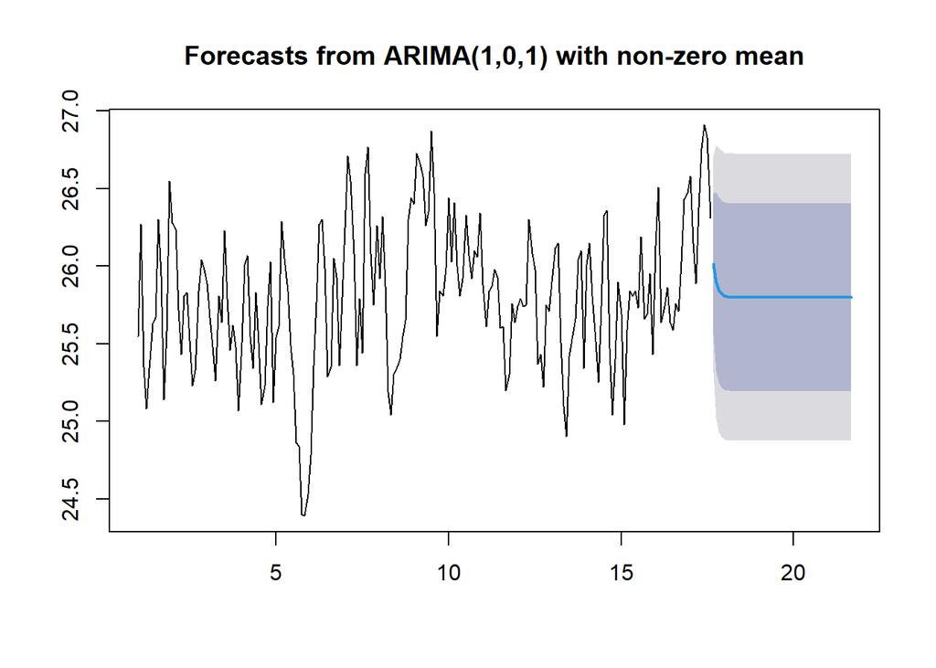

```r
data.ramalan <- ramalan$mean
plot(ramalan)
```

# AKURASI

```r
perbandingan <- matrix(data=c(head(dt.uji.ts, n=49), data.ramalan),
                     nrow = 49, ncol = 2)
colnames(perbandingan) <- c("Aktual","Hasil Forecast")
perbandingan
```

```
##       Aktual Hasil Forecast
##  [1,]  26.80       26.01361
##  [2,]  27.10       25.89949
##  [3,]  27.07       25.84607
##  [4,]  27.58       25.82107
##  [5,]  26.74       25.80936
##  [6,]  26.37       25.80388
##  [7,]  26.19       25.80132
##  [8,]  26.05       25.80012
##  [9,]  26.37       25.79956
## [10,]  26.59       25.79929
## [11,]  26.62       25.79917
## [12,]  26.15       25.79911
## [13,]  25.66       25.79909
## [14,]  25.70       25.79907
```

[output cut: 35 more lines]

```r
#accuracy(data.ramalan, head(dt.uji.ts, n=49))
```